# Claim risk analytics for an insurance company

Piyush Verma

June 24, 2018

## **Introduction**

1. Identify the potential:
   1. non-risky 2018 customers
   2. low risy 2018 customers
2. Risk-profiling for all the risky 2018 customers, based on features from 2017 data.

The objectives are centered at marketing campaigns engaging future 2018 customers based on their risk profiles.

## **Loading libraries and reading files**

```r
library(readr)
library(ggplot2)
library(lubridate)
library(dplyr)
library(VIM)
library(mice)
library(corrplot)
library(randomForest)
library(Matrix)
library(ROCR)
library(xgboost)
library(caret)
library(car)
library(cluster)
library(Rtsne)
library(RODBC)
library(dplyr)
library(kableExtra)
library(Metrics)    # For calculating auc
library(GGally)

raw_data_2017 <- suppressMessages(as.data.frame(read_csv("./auto_policies_2017.csv")))
numclaims<-raw_data_2017$numclaims
claimcst0<-raw_data_2017$claimcst0
raw_data_2018 <- suppressMessages(as.data.frame(read_csv("./auto_potential_customers_2018.csv")))
quote_number<-raw_data_2018$quote_number
```

## **Data Processing**

The data had many missing values for:

1. *claim_office (83%)*: Office were claim was made
2. *agecat (8%)*: Age category of the driver

Proportion of missing values for each feature and combination of features was best understood from the plot below:

1. Only 13% observations have all values, rest of 87% observations missed values for one, two, three or four features
2. Since 83% observations have missing values for claim_office, which is more than recommended 5%, it was removed

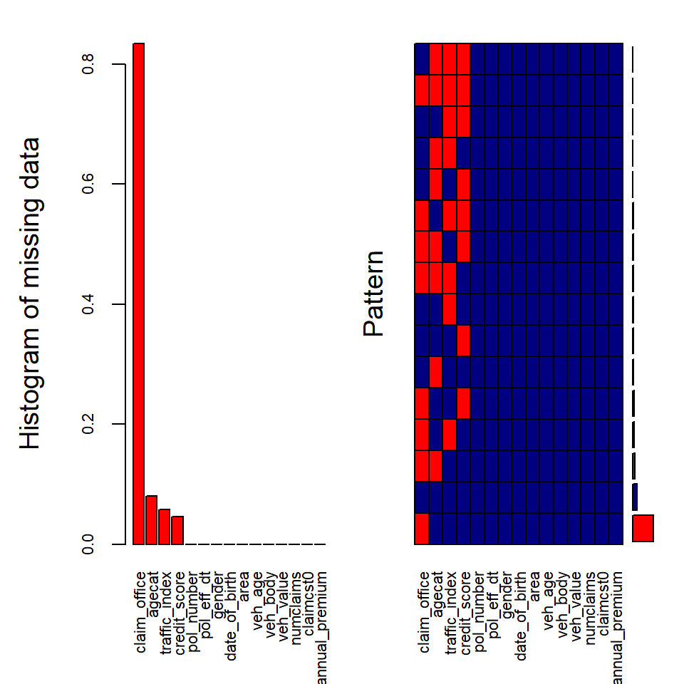

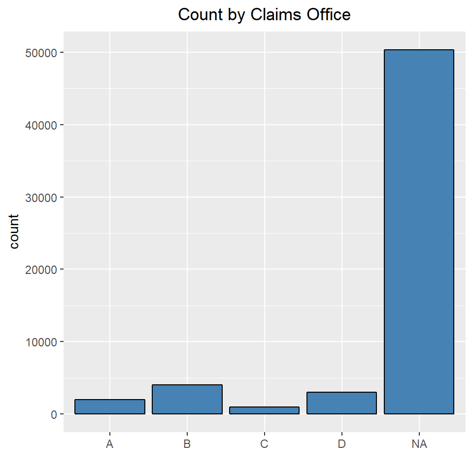

Preview of the data:

| pol_number | pol_eff_dt | gender | agecat | date_of_birth | credit_score | area | traffic_index | veh_age | veh_body | veh_value | numclaims | claimcst0 | annual_premium | age |
| --- | --- | --- | --- | --- | --- | --- | --- | --- | --- | --- | --- | --- | --- | --- |
| 64080188 | 7/10/2017 | M | 2 | 1989-01-04 | 631 | B | 140.9 | 4 | TRUCK | 0.924 | 0 | 0.0000 | 716.53 | 29 |
| 18917133 | 7/31/2017 | M | 2 | 1985-06-21 | 531 | C | 136.5 | 3 | HBACK | 1.430 | 1 | 583.0109 | 716.53 | 33 |
| 82742606 | 2/1/2017 | M | 6 | 1942-07-25 | 838 | D | 88.8 | 3 | SEDAN | 1.100 | 1 | 159.3758 | 716.53 | 76 |
| 43601997 | 10/17/2017 | M | 5 | 1959-06-08 | 835 | E | NA | 2 | SEDAN | 2.090 | 0 | 0.0000 | 716.53 | 59 |
| 58746861 | 4/13/2017 | F | 4 | 1967-05-16 | 748 | C | 123.0 | 3 | HBACK | 0.803 | 1 | 143.5556 | 716.53 | 51 |
| 83346346 | 11/23/2017 | M | 5 | 1956-11-02 | 785 | B | 108.6 | 2 | SEDAN | 1.903 | 0 | 0.0000 | 716.53 | 61 |
| 92111059 | 11/29/2017 | M | 3 | 1976-10-31 | 759 | E | 75.0 | 4 | STNWG | 1.452 | 0 | 0.0000 | 716.53 | 41 |
| 69967688 | 4/24/2017 | F | NA | 1947-11-27 | 836 | C | 88.5 | 1 | HBACK | 1.397 | 0 | 0.0000 | 716.53 | 70 |
| 58856161 | 7/19/2017 | M | NA | 1967-03-12 | 688 | A | 50.0 | 1 | SEDAN | 2.838 | 0 | 0.0000 | 716.53 | 51 |
| 57786319 | 8/31/2017 | M | NA | 1984-12-25 | 503 | B | NA | 3 | HBACK | 1.936 | 1 | 1039.3983 | 716.53 | 33 |
| 42491309 | 3/24/2017 | F | 3 | 1974-10-08 | 830 | D | 132.2 | 4 | STNWG | 1.485 | 0 | 0.0000 | 716.53 | 43 |
| 66944935 | 7/20/2017 | F | 2 | 1982-08-31 | 649 | E | 27.0 | 2 | STNWG | 3.641 | 0 | 0.0000 | 716.53 | 35 |
| 66147210 | 5/24/2017 | M | 4 | 1968-03-30 | 424 | D | 84.2 | 4 | TRUCK | 1.595 | 1 | 5087.3893 | 716.53 | 50 |
| 73105575 | 9/1/2017 | M | NA | 1969-08-28 | 792 | A | 85.4 | 1 | HBACK | 1.518 | 0 | 0.0000 | 716.53 | 48 |
| 51922471 | 7/4/2017 | F | NA | 1975-10-06 | 652 | A | 77.7 | 4 | HBACK | 0.495 | 0 | 0.0000 | 716.53 | 42 |
| 61781876 | 5/11/2017 | F | 3 | 1970-01-27 | 843 | D | 88.0 | 3 | SEDAN | 1.078 | 0 | 0.0000 | 716.53 | 48 |
| 72643150 | 3/20/2017 | F | 3 | 1970-11-13 | 660 | C | 148.5 | 1 | STNWG | 5.566 | 0 | 0.0000 | 716.53 | 47 |
| 29718559 | 10/11/2017 | F | 1 | 1990-11-04 | 546 | D | 41.5 | 2 | SEDAN | 1.716 | 1 | 5096.5742 | 716.53 | 27 |
| 42078978 | 11/6/2017 | M | 4 | 1968-11-19 | 775 | B | 132.5 | 4 | PANVN | 0.495 | 0 | 0.0000 | 716.53 | 49 |
| 35887851 | 1/9/2017 | F | 3 | 1976-11-18 | 661 | A | 84.3 | 3 | SEDAN | 1.232 | 0 | 0.0000 | 716.53 | 41 |

## **Missing value imputation**

Missing values for variable agecat, `credit_score` and `traffic_index` were imputed in this section. `agecat` for missing values was calculated using `date_of_birth` and continuous variables: `credit_score` and `traffic_index` were imputed using `MICE` package. The technique used for their imputation was: `Predictive Mean Matching (pmm)`. The data was found to be missing randomly (ideal scenario). For example, in the plot below; **red** left vertical boxplot shows the distribution of `credit_score` where `traffic_index` is missing and **blue** left vertical boxplot shows where both are present. Same analogy for the bottom horizontal boxplots.

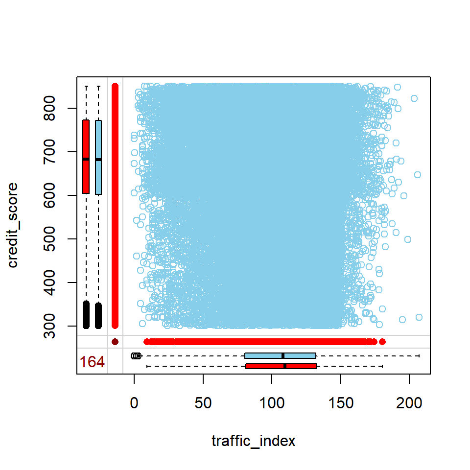

For imputing the missing data in both the 2017 (training) & 2018 (testing) datasets, 2018 data was first appended to 2017 data and then the missing value was imputed for `NA`s in both the sets.

Below plot shows that all the missing values have been immputed now.

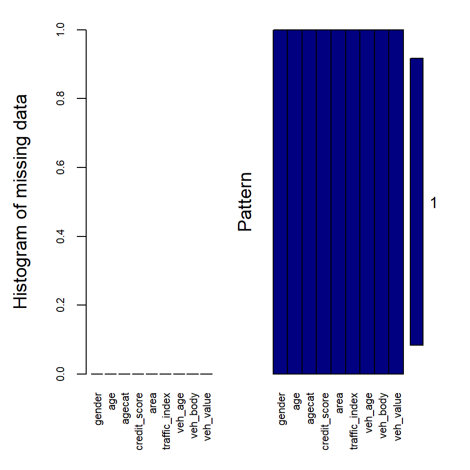

```r
# Training Dataset
raw_data_2017<-raw_data_2017 %>%
  mutate(agecat = ifelse(is.na(agecat),
                         ifelse(18<=age & age<28,1,
                                ifelse(28<=age & age<38,2,
                                       ifelse(38<=age & age<48,3,
                                              ifelse(48<=age & age<58,4,
                                                     ifelse(58<=age & age<68,5,6))))),agecat))
# Testing Dataset
raw_data_2018<-raw_data_2018 %>%
  mutate(agecat = ifelse(is.na(agecat),
                         ifelse(18<=age & age<28,1,
                                ifelse(28<=age & age<38,2,
                                       ifelse(38<=age & age<48,3,
                                              ifelse(48<=age & age<58,4,
                                                     ifelse(58<=age & age<68,5,6))))),agecat))
# Keeping only relevant columns ftr the imputing process
raw_data_2017<-raw_data_2017[,c("gender","age","agecat","credit_score","area","traffic_index","veh_age","veh_body","veh_value")]
raw_data_2018<-raw_data_2018[,c("gender","age","agecat","credit_score","area","traffic_index","veh_age","veh_body","veh_value")]
# Correcting Data Types
raw_data_2017$gender<-as.factor(raw_data_2017$gender)
raw_data_2017$agecat<-as.factor(raw_data_2017$agecat)
raw_data_2017$area<-as.factor(raw_data_2017$area)
raw_data_2017$veh_body<-as.factor(raw_data_2017$veh_body)
raw_data_2018$gender<-as.factor(raw_data_2018$gender)
raw_data_2018$agecat<-as.factor(raw_data_2018$agecat)
raw_data_2018$area<-as.factor(raw_data_2018$area)
raw_data_2018$veh_body<-as.factor(raw_data_2018$veh_body)
# Imputing the missing data using MICE package
combined_data<-rbind(raw_data_2017,raw_data_2018)
init = mice(combined_data, maxit=0)
meth = init$method
meth[c("gender")]=""
meth[c("age")]=""
meth[c("agecat")]=""
meth[c("area")]=""
meth[c("veh_age")]=""
meth[c("veh_body")]=""
meth[c("veh_value")]=""
meth[c("credit_score")]="pmm"
meth[c("traffic_index")]="pmm"
imputed = mice(combined_data, method=meth, m=1,maxit = 5,seed = 500)
imputed <- complete(imputed)
aggr_plot <- aggr(imputed, col=c('navyblue','red'), numbers=TRUE, sortVars=TRUE,
                  labels=names(imputed), cex.axis=.7, gap=3, ylab=c("Histogram of missing data","Pattern"))
```

Next, a **binary response variable was created** in 2017 data as `claim_YN` based on column `claimcst0` (1 if some amount was claimed 0 if no amount was claimed).

# **SECTION 1:**

## **IDENTIFYING POTENTIAL NON-RISKY AND LOW-RISK 2018 CUSTOMERS**

```r
index<-1:60392
imp_2017<-imputed[index,]
imp_2018<-imputed[-index,]
imp_2017<-cbind(imp_2017,numclaims,claimcst0)
imp_2017$claim_YN<-as.factor(ifelse(claimcst0>0,1,0)) # Response needs to be a category
```

```r
# Changing vehicles with 0 value to max of their vehicle_age + vehicle_body category
imp_2017<-imp_2017 %>%
  mutate(veh_value = ifelse(veh_value==0,
                            ifelse(veh_body=="BUS",7.1830,
                                   ifelse(veh_body=="MCARA",13.6400,
                                          ifelse(veh_body=="MIBUS",5.0160,
                                                 ifelse(veh_body=="SEDAN",24.9590,
                                                        ifelse(veh_body=="STNWG",12.5400,6.2700))))),veh_value))

imp_2018<-imp_2018 %>%
  mutate(veh_value = ifelse(veh_value==0,
                            ifelse(veh_body=="BUS",7.1830,
                                   ifelse(veh_body=="MCARA",13.6400,
                                          ifelse(veh_body=="MIBUS",5.0160,
                                                 ifelse(veh_body=="SEDAN",24.9590,
                                                        ifelse(veh_body=="STNWG",12.5400,6.2700))))),veh_value))
```

Preview after cleaning and imputation:

| gender | age | agecat | credit_score | area | traffic_index | veh_age | veh_body | veh_value | numclaims | claimcst0 | claim_YN |
| --- | --- | --- | --- | --- | --- | --- | --- | --- | --- | --- | --- |
| M | 29 | 2 | 631 | B | 140.9 | 4 | TRUCK | 0.924 | 0 | 0.0000 | 0 |
| M | 33 | 2 | 531 | C | 136.5 | 3 | HBACK | 1.430 | 1 | 583.0109 | 1 |
| M | 76 | 6 | 838 | D | 88.8 | 3 | SEDAN | 1.100 | 1 | 159.3758 | 1 |
| M | 59 | 5 | 835 | E | 28.5 | 2 | SEDAN | 2.090 | 0 | 0.0000 | 0 |
| F | 51 | 4 | 748 | C | 123.0 | 3 | HBACK | 0.803 | 1 | 143.5556 | 1 |
| M | 61 | 5 | 785 | B | 108.6 | 2 | SEDAN | 1.903 | 0 | 0.0000 | 0 |
| M | 41 | 3 | 759 | E | 75.0 | 4 | STNWG | 1.452 | 0 | 0.0000 | 0 |
| F | 70 | 6 | 836 | C | 88.5 | 1 | HBACK | 1.397 | 0 | 0.0000 | 0 |
| M | 51 | 4 | 688 | A | 50.0 | 1 | SEDAN | 2.838 | 0 | 0.0000 | 0 |
| M | 33 | 2 | 503 | B | 134.1 | 3 | HBACK | 1.936 | 1 | 1039.3983 | 1 |
| F | 43 | 3 | 830 | D | 132.2 | 4 | STNWG | 1.485 | 0 | 0.0000 | 0 |
| F | 35 | 2 | 649 | E | 27.0 | 2 | STNWG | 3.641 | 0 | 0.0000 | 0 |
| M | 50 | 4 | 424 | D | 84.2 | 4 | TRUCK | 1.595 | 1 | 5087.3893 | 1 |
| M | 48 | 4 | 792 | A | 85.4 | 1 | HBACK | 1.518 | 0 | 0.0000 | 0 |
| F | 42 | 3 | 652 | A | 77.7 | 4 | HBACK | 0.495 | 0 | 0.0000 | 0 |
| F | 48 | 3 | 843 | D | 88.0 | 3 | SEDAN | 1.078 | 0 | 0.0000 | 0 |
| F | 47 | 3 | 660 | C | 148.5 | 1 | STNWG | 5.566 | 0 | 0.0000 | 0 |
| F | 27 | 1 | 546 | D | 41.5 | 2 | SEDAN | 1.716 | 1 | 5096.5742 | 1 |
| M | 49 | 4 | 775 | B | 132.5 | 4 | PANVN | 0.495 | 0 | 0.0000 | 0 |
| F | 41 | 3 | 661 | A | 84.3 | 3 | SEDAN | 1.232 | 0 | 0.0000 | 0 |

## **Data Exploration**

Below plots were generated to understand the pattern of claims across variables.

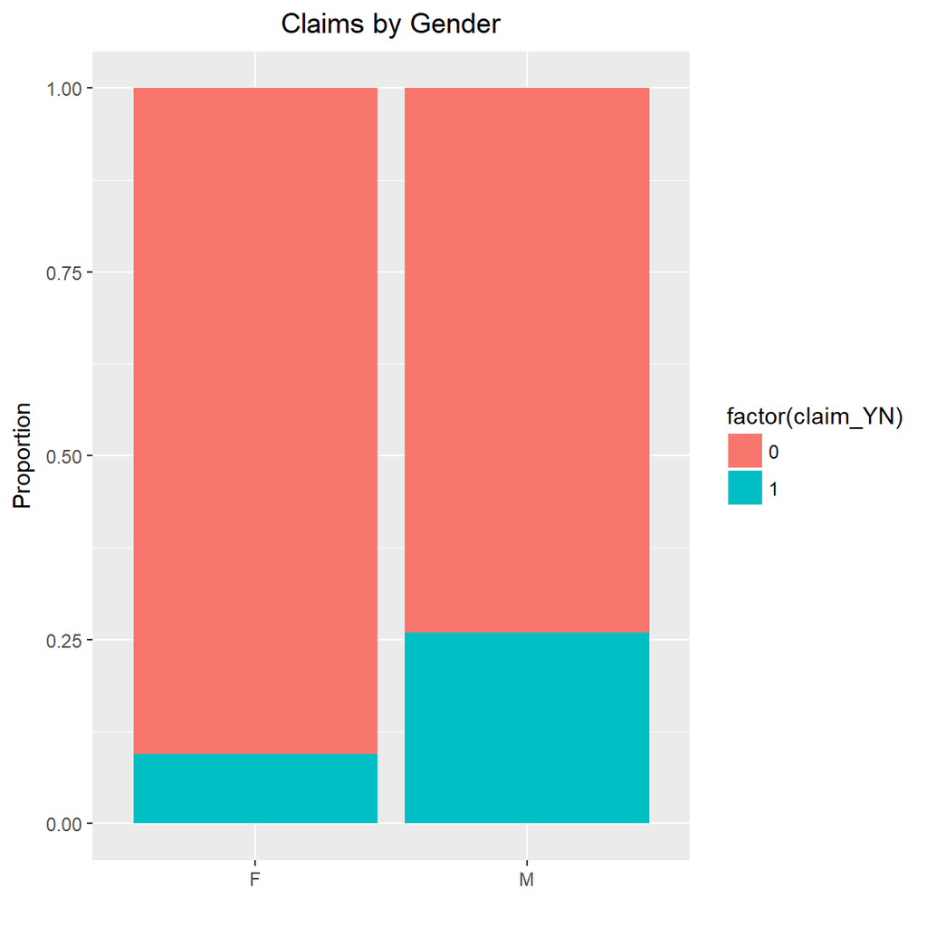

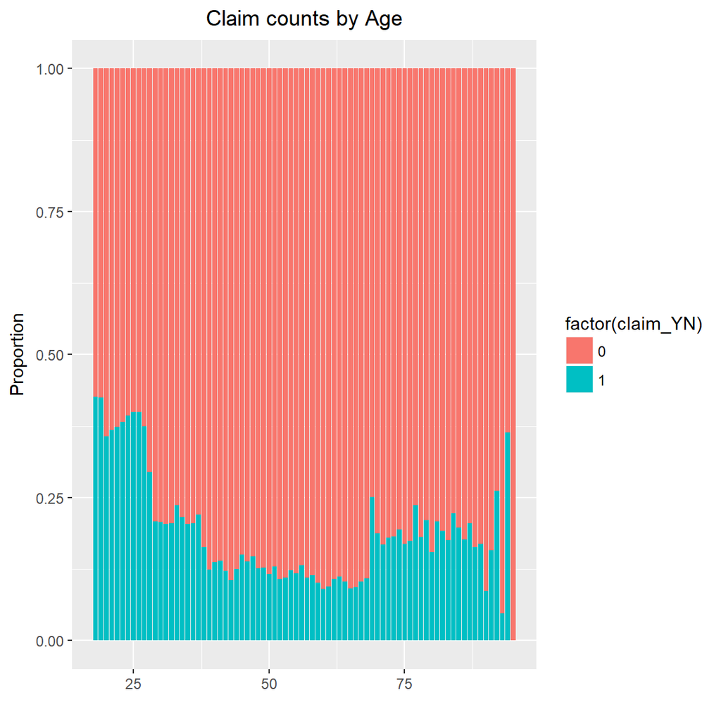

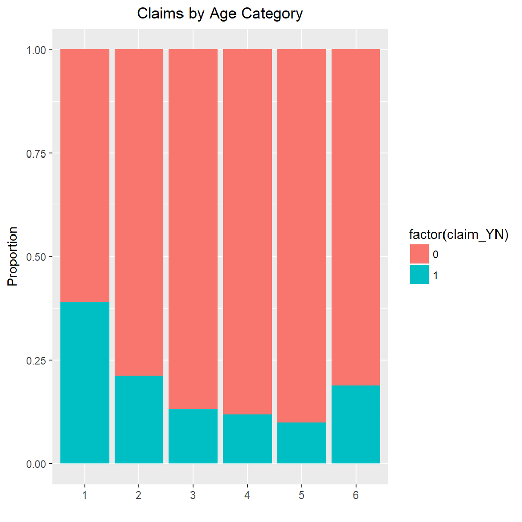

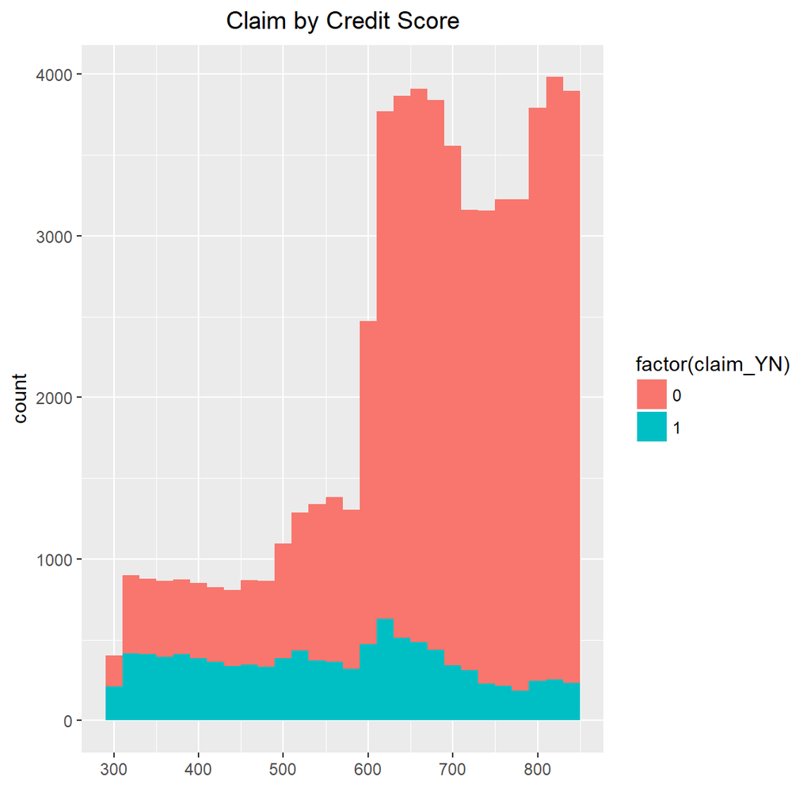

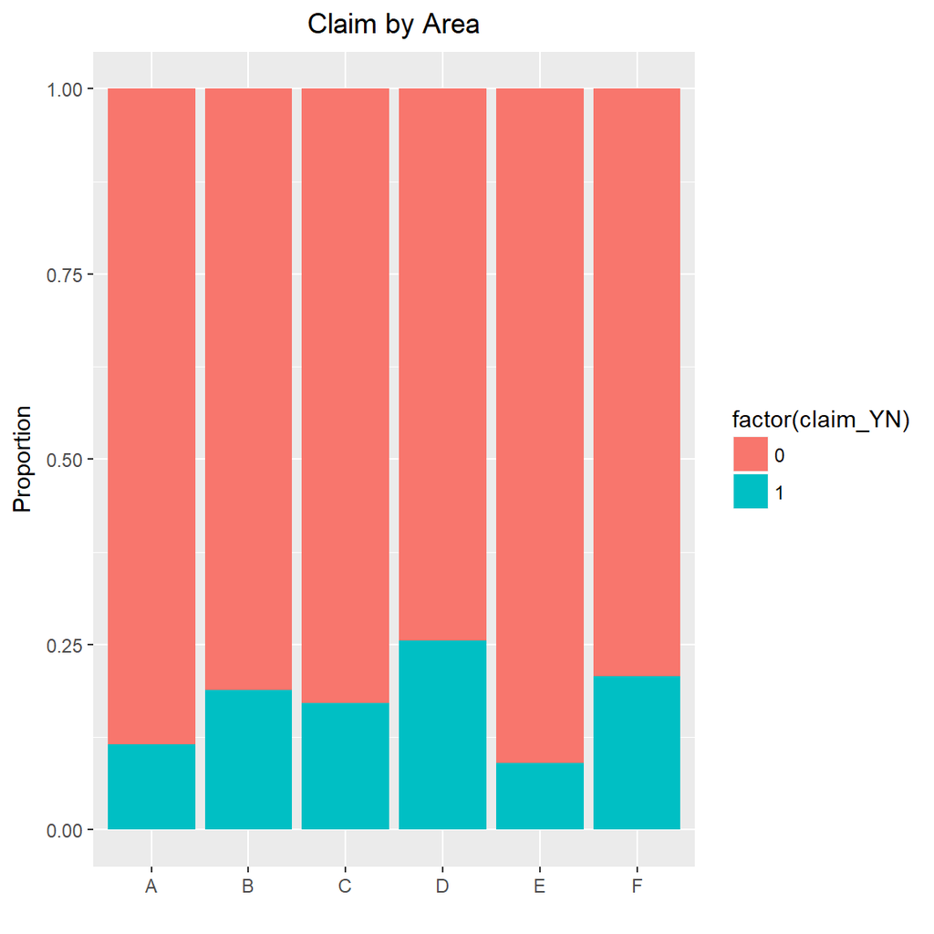

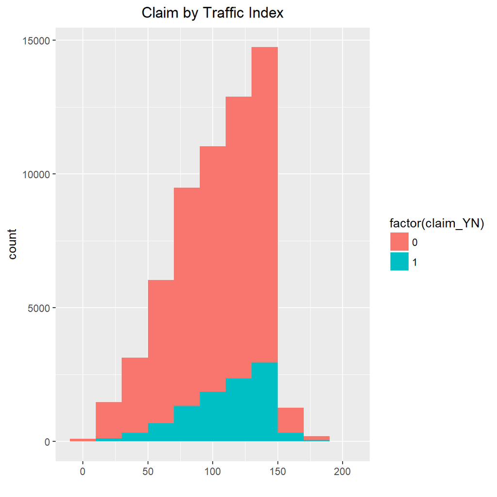

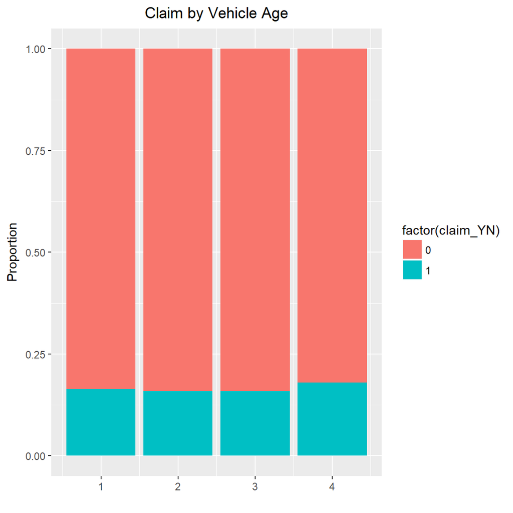

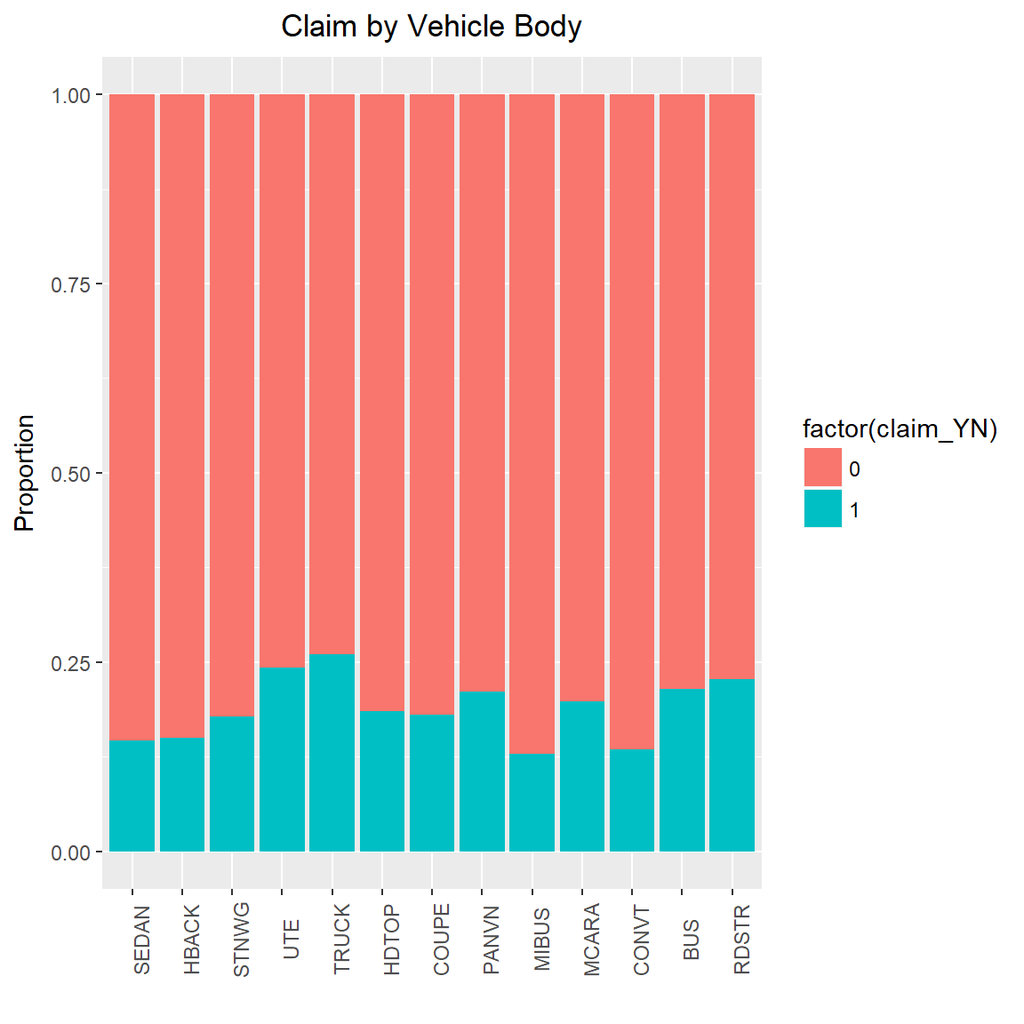

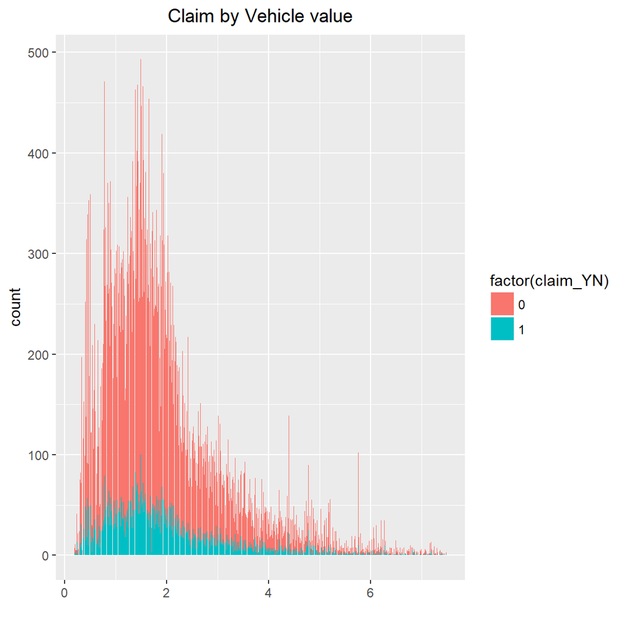

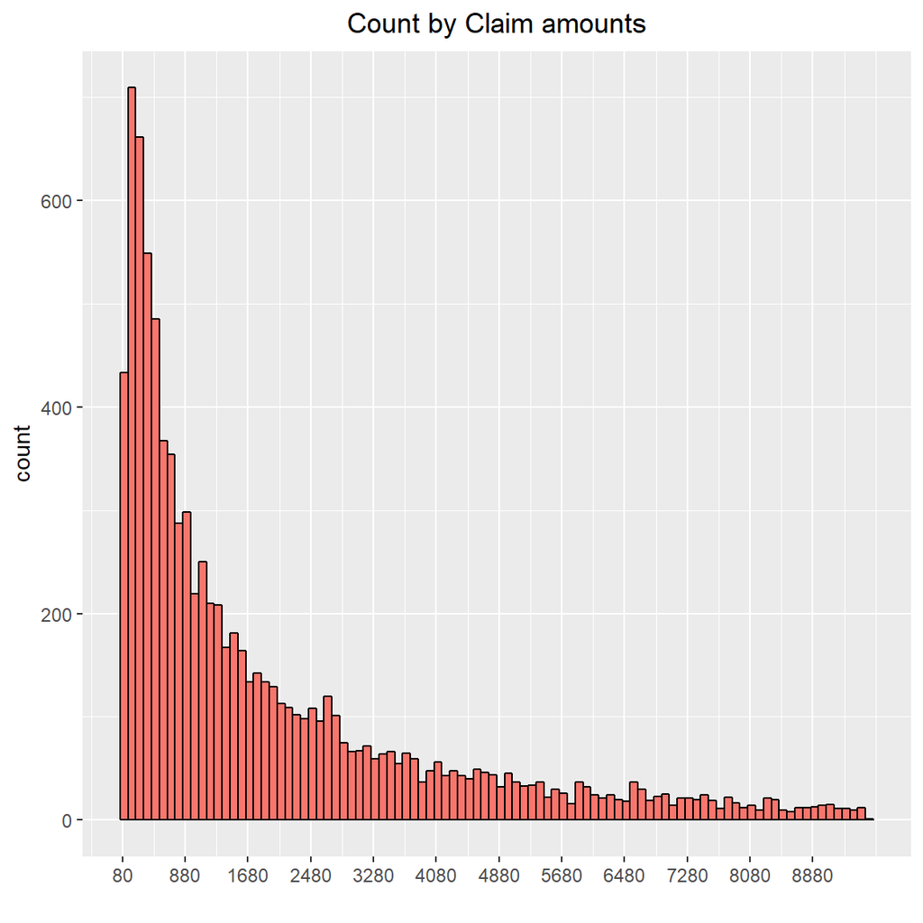

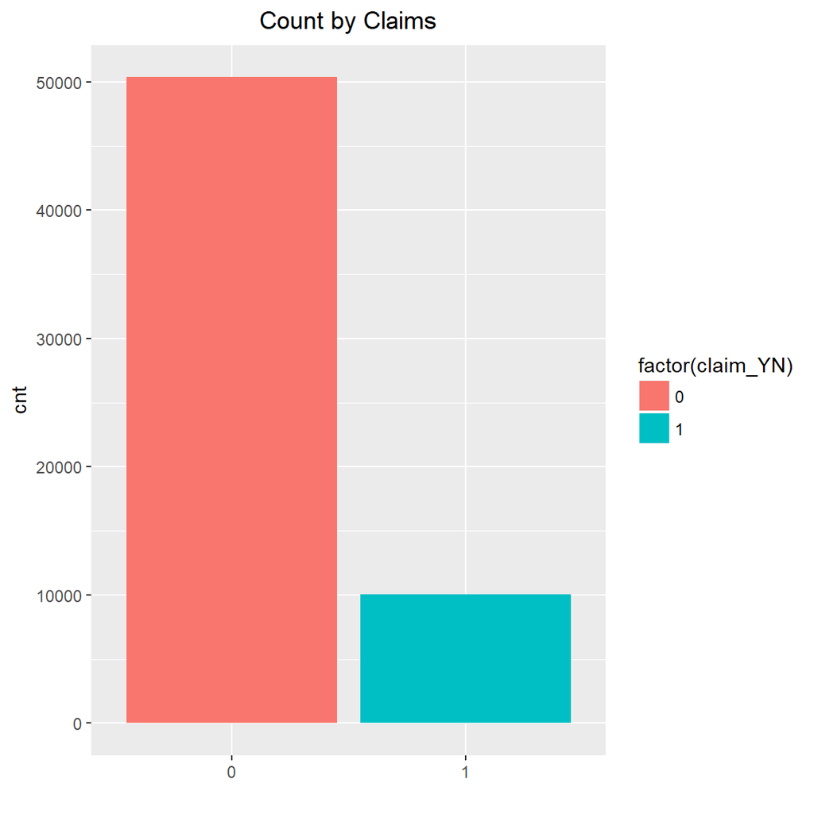

Following conclusions were drawn from the exploratory data analysis:

# **Correlation**

From the correlation matrix and jitter plot below we can say that:

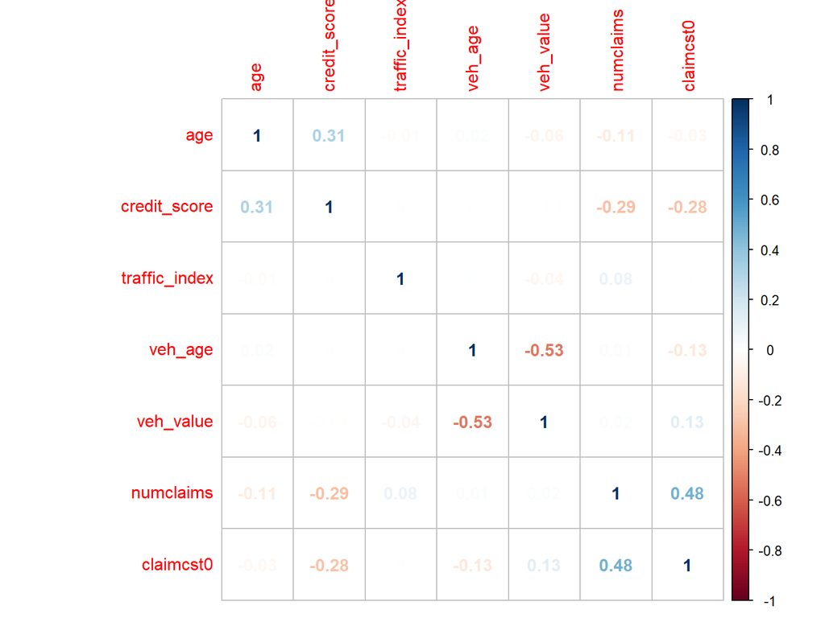

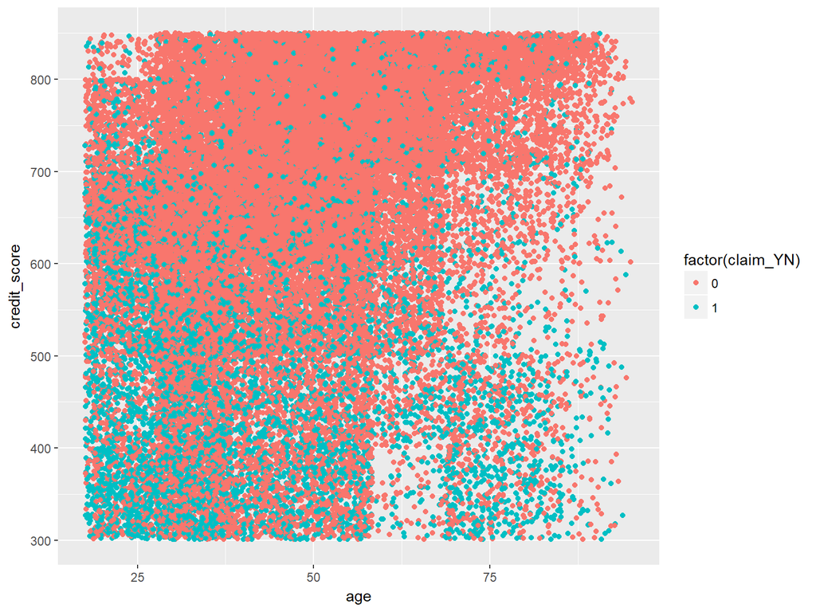

# **Data Modelling**

After data processing and exploration, modelling was started with splitting the 2017 data into training (80%) and validation (20%) (pareto rule). A seed was set to make the results reproducible. Both the resulting training and validation (*named testing here*) had 16% of claims.

Three machine learning models were fit onto the training dataset for classification of potentially risky and non-risky claims.

### **Logistic Model**

Logistic Regression was used as the baseline model to compare other models. ***AUC and misclassification rate were checked** for the validation set and the model which had the highest AUC and misclassification rate was selected for further comaprison with non-linear models. To start with , total three logistic models were compared:

**Model 1:** `claim_YN ~ .`

**Model 2:** `claim_YN ~ . - agecat`

**Model 3:** `claim_YN ~ . - agecat - veh_age - veh_body`

```r
log.fit1<-glm(claim_YN ~ .,family=binomial(link='logit'),data=training)
log.fit2<-glm(claim_YN ~ .-agecat,family=binomial(link='logit'),data=training)
log.fit3<-glm(claim_YN ~ .-agecat -veh_age -veh_body ,family=binomial(link='logit'),data=training)
log.pred<-predict(log.fit2,testing,type = "response")
```

Out of above three models, `Model 2` was selected because:

1. it doesn’t contain one of the redundant variables: `agecat` removed in order to reduce the variance inflation
2. `Model 2` AIC value is slightly lower than model 3

```r
AIC(log.fit2)
```

```
## [1] 34246.53
```

```r
AIC(log.fit3)
```

```
## [1] 34253.97
```

Notable observations from Logistic Model `Model 2`:

1. Response `claim_YN` has some linear relationship with `gender`, `age`, `credit_score`, `area` and `traffic_index`
2. Response `claim_YN` doesn’t have linear relationship with other variables like `veh_value`, `veh_age` and `veh_body`

So logistic model says that features related to vehicles don’t play any role in claim.

### **Random Forest**

1. Random Forest unearthed a possible **non-linear** relationship of `claim_YN` with `veh_value`, which logistic model was missing out

```r
set.seed(500)
rf.fit<-randomForest(claim_YN ~ .-agecat,ntree = 100, data = training)
rf.pred<-predict(rf.fit,testing,type = "prob")[,2]
```

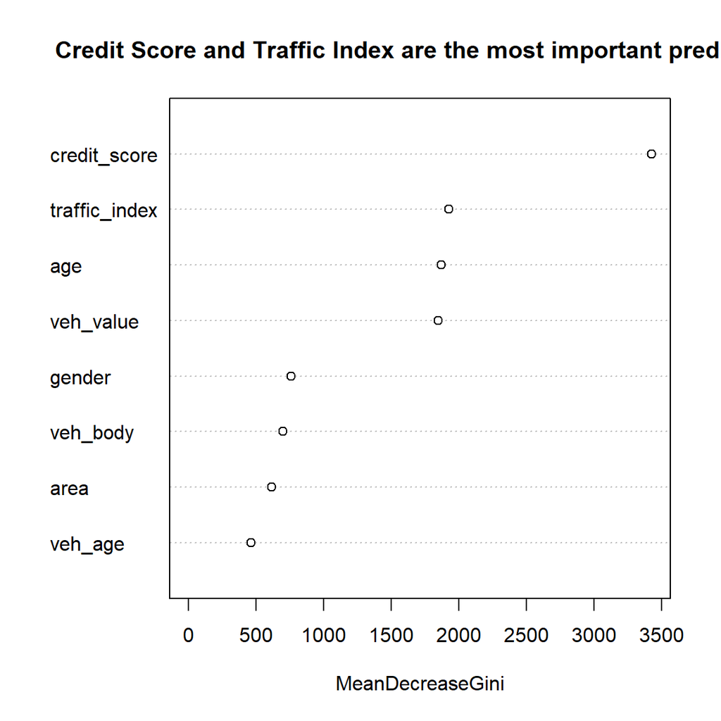

### **Xtreme Boosting**

Lastly `xgboost` model was fit. Here the model without `agecat` was better than a full model and a subset model in terms of misclassification rate o nthe validation set.

```r
predictors<-c("gender","age","credit_score","area","traffic_index","veh_age","veh_body","veh_value")
output_vector<-as.numeric(training[,"claim_YN"])-1
sparse_matrix_train <- sparse.model.matrix(claim_YN ~ ., data = training[,-3])[,-1]
sparse_matrix_test <- sparse.model.matrix(claim_YN ~ ., data = testing[,-3])[,-1]
set.seed(500)
xg.fit <- xgboost(data = sparse_matrix_train, label = output_vector, max_depth = 6,
               eta = 0.3, nthread = 2, nrounds = 200,objective = "binary:logistic")
xgb.pred<-predict(xg.fit, sparse_matrix_test)
```

Below plot indicates the important variables:

1. `traffic_index` and `credit_score` still seem to be the most important predictors, followed by `gender`, `age` and `veh_value`

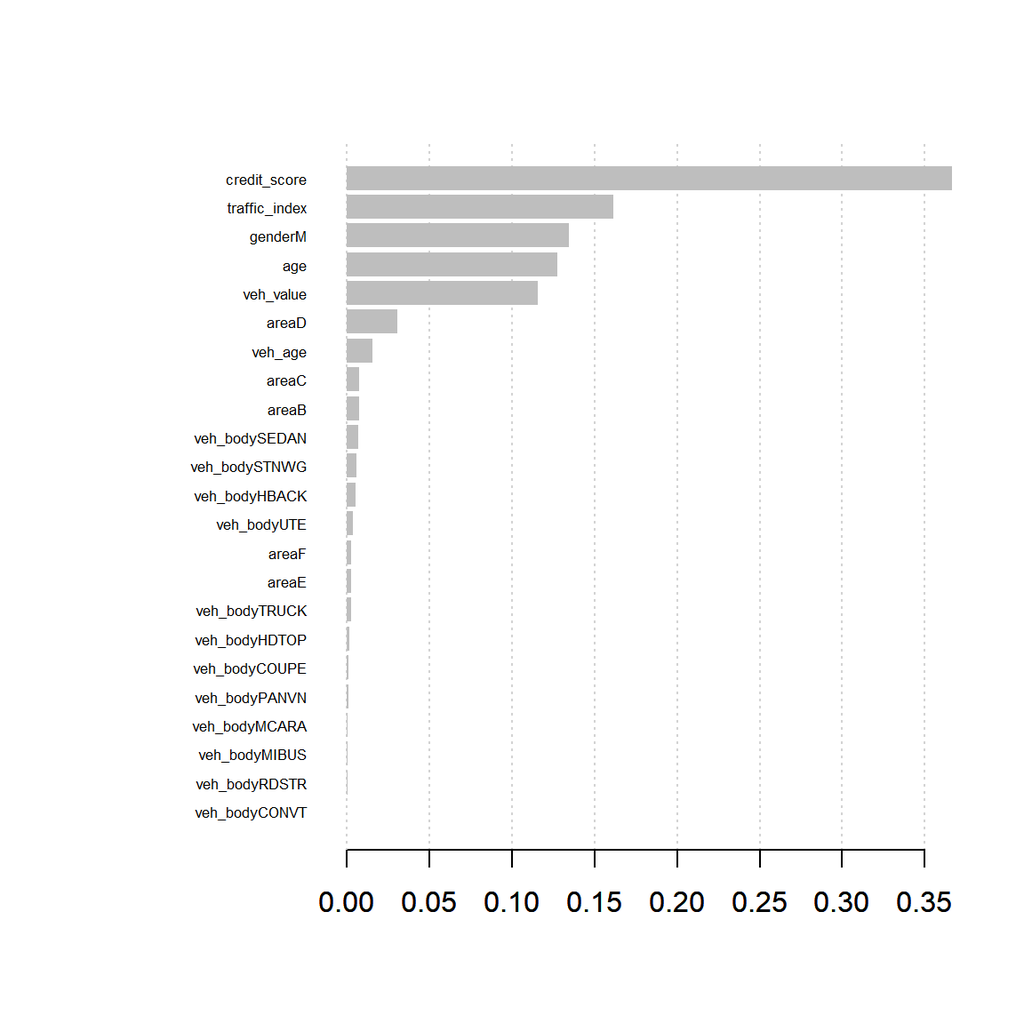

# **Model Comparison**

Below plot shows the AUC curves for all the three models and reveals that **logistic model** is so far the best model.

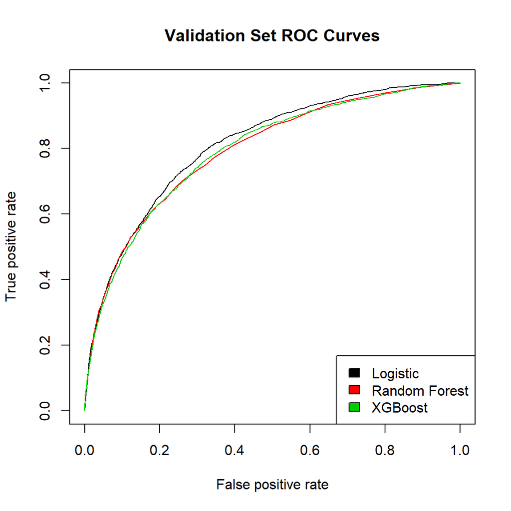

| Model | AUC |
| --- | --- |
| Logistic Regression | 0.8096599 |
| Random Forest | 0.7937251 |
| XGBoost | 0.7928353 |

### **Grid Search for cutoff probability**

Logistic model `Model 2` was finalized because of its **higher AUC** value. Now using this model a cutoff probability was determined using the gridsearch in order to minimize the misclassification rate. A cutoff probabilty would determine what risk probability is enough beyond which we can’t classify someone as a sale customer.

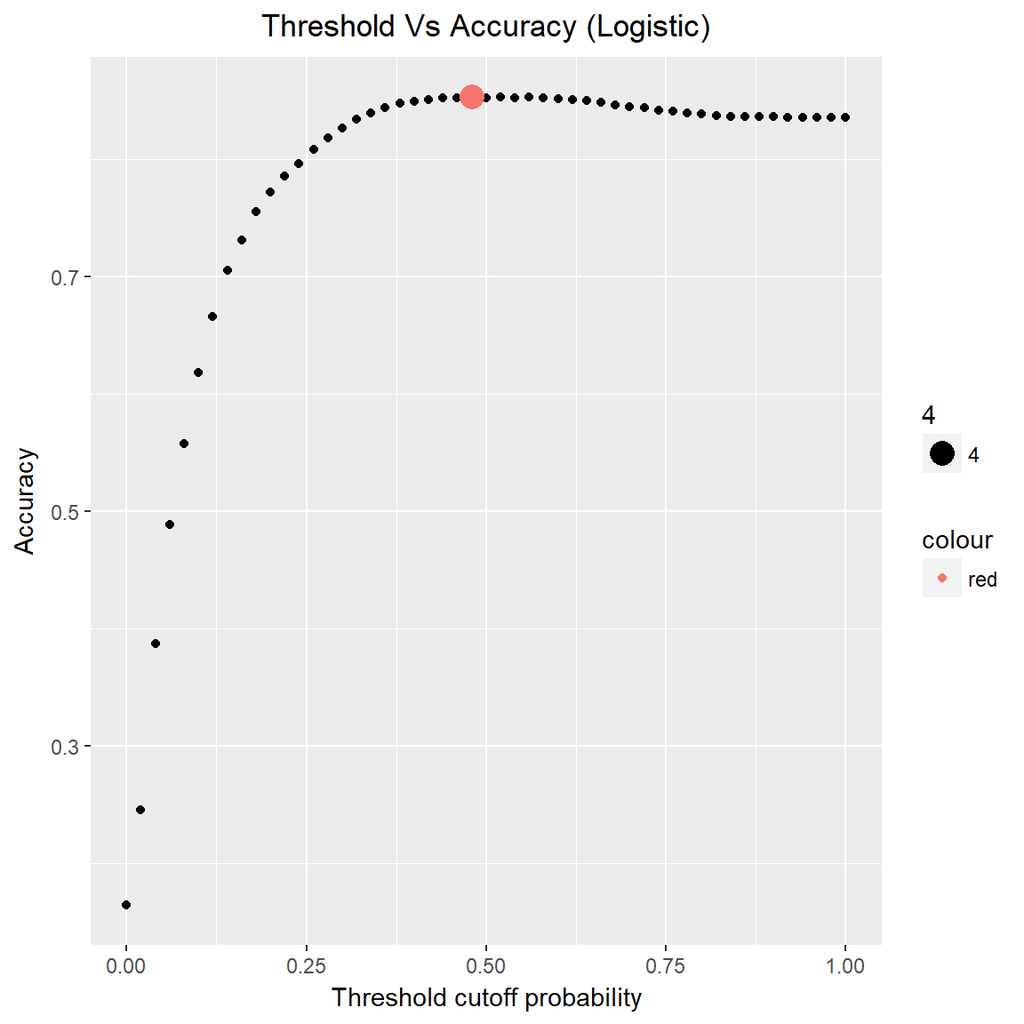

```r
pr<-seq(0,1,0.02)
accry<-c()
for(i in 1:length(pr)){
  log.pred<-ifelse(predict(log.fit2,testing,type = "response") >= pr[i],1,0)
  accry[i]<-sum(log.pred == testing$claim_YN)/nrow(testing)
}
log.tab<-data.frame(cbind("prob" = pr, "accuracy" = accry))
ggplot(log.tab,aes(x=prob,y=accuracy)) +
  geom_point(show.legend=F) +
  xlab("Threshold cutoff probability") +
  ylab("Accuracy") +
  ggtitle("Threshold Vs Accuracy (Logistic)") + theme(plot.title = element_text(hjust=0.5)) +
  geom_point(aes(x=log.tab[log.tab$accuracy==max(log.tab$accuracy),][[1]],y=log.tab[log.tab$accuracy==max(log.tab$accuracy),][[2]],colour="red",cex=4))
```

Final predictions were made using the above found cutoff probability (0.48) and saved in the file.

```r
final_predictions<-data.frame(cbind("Quote Numbers" = quote_number,imp_2018,"Risk" = ifelse(predict(log.fit1,imp_2018,type = "response")>=0.48,1,0)))
table(final_predictions$Risk)
potential_non_risky<-data.frame("Quote Numbers" = final_predictions[final_predictions$Risk==0,1])
potential_risky<-data.frame("Quote Numbers" = final_predictions[final_predictions$Risk==1,1])
write.csv(potential_non_risky,"potential_non_risky_customers.csv", row.names = FALSE)
```

# **SECTION 2:**

## **IDENTIFYING POTENTIAL LOW RISK CUSTOMERS**

**ASSUMPTON:** LOW RISK customers needed to be defined. So in this section we would mean the bottom 15% customers in terms of risk among all risky customers. (This is %ile can be any number according to business requirement).

Section 1 identified potential risky customers, this section calculated the potential cost for the claims in the cases where we can expect a claim to happen. Below code calculates the cost per claim per policy by taking the ratio of `claimcst0` & `numclaims`, after filtering for risky customers only.

```r
claim_cust<-imp_2017 %>%
  mutate(cost_per_claim = ifelse(is.nan(claimcst0/numclaims),0,round((claimcst0/numclaims),2))) %>%
  select(-c(10:12)) %>%
  filter(cost_per_claim>0)
```

Below corrleation matrix and histogram suggest that:

1. New variable `cost_per_claim` is mildly correlated with `veh_age` and `veh_value`
2. `cost_per_claim` is highly skewed (and thus needs a log transformation)

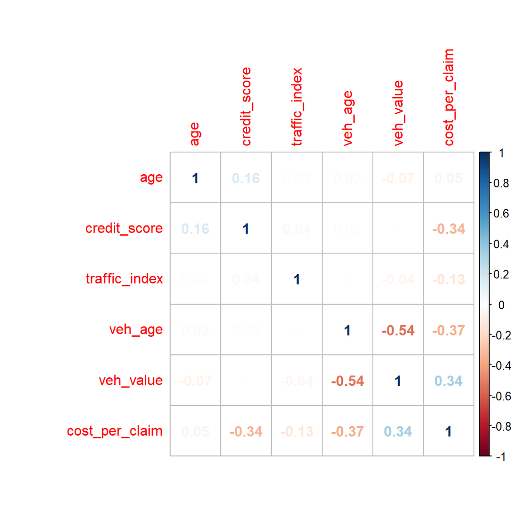

**Before log transformation:**

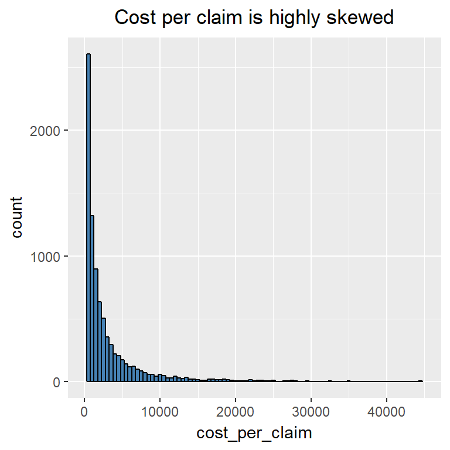

**After log transformation:**

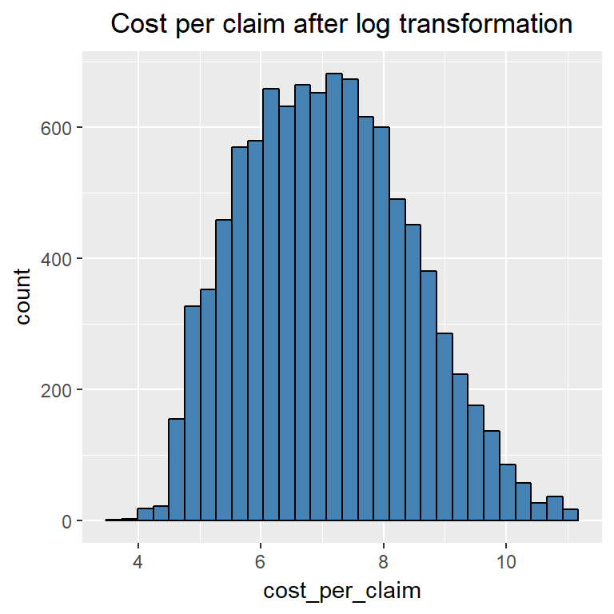

# **Data Modelling**

Once again we would split our data into 80-20.

```r
set.seed(500)
index<-sample(nrow(claim_cust),0.8*nrow(claim_cust),replace = FALSE)
training<-claim_cust[index,]
testing<-claim_cust[-index,]
```

### **Multiple Linear Regression**

Multiple Linear Regression was used as the baseline model to compare other models. **Mean Squared Error** was checked for the validation set and the linear model which had the lowest **MSE** was selected for further comaprison with non-linear models. To start with, total three linear models were compared:

**Model 1:** `cost_per_claim ~ .`

**Model 2:** `cost_per_claim ~ .- agecat`

**Model 3:** `cost_per_claim ~ .-veh_age -agecat`

Notable observations (after looking at model `summaries`):

1. In full model `Model 1`, coefficient sign of `age` changed from -ve to +ve showing its collinearity with `agecat`
2. After removing `veh_age`, the positive coefficient of `veh_value` increased (showing effect of collinearity with `veh_age`)

```r
lm.cpc.fit1<-lm(cost_per_claim ~ .,data = training)
lm.cpc.fit2<-lm(cost_per_claim ~ .- agecat,data = training)
lm.cpc.fit3<-lm(cost_per_claim ~ .-veh_age -agecat,data = training)
lm.mse1<-sum((predict(lm.cpc.fit1,testing)-testing$cost_per_claim)^2)/nrow(testing)
lm.mse2<-sum((predict(lm.cpc.fit2,testing)-testing$cost_per_claim)^2)/nrow(testing)
lm.mse3<-sum((predict(lm.cpc.fit3,testing)-testing$cost_per_claim)^2)/nrow(testing)
```

`Model 1` was selected among linear models for further comparison becuase of its low MSE 0.4438146 (others being 0.524292 & 0.6931242).

### **Residual Analysis**

Below is the residual plot which assures that the normality assumption was not violated.

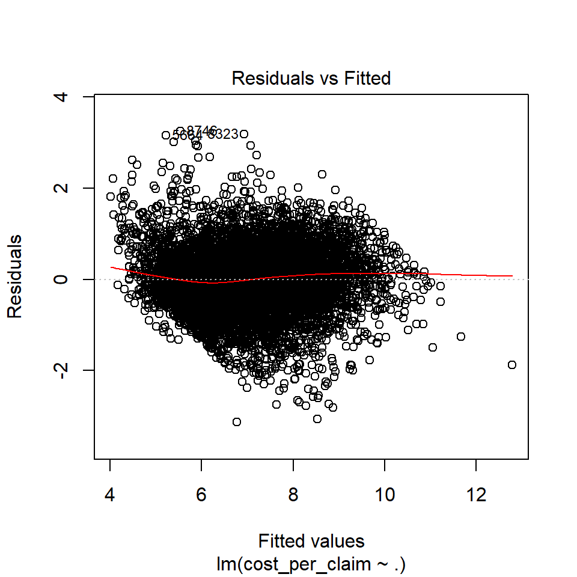

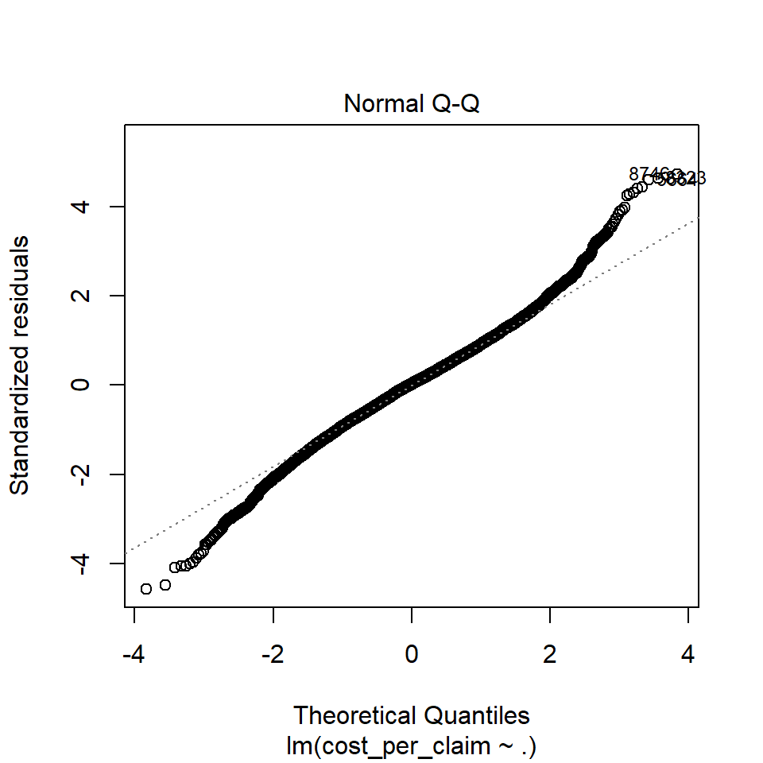

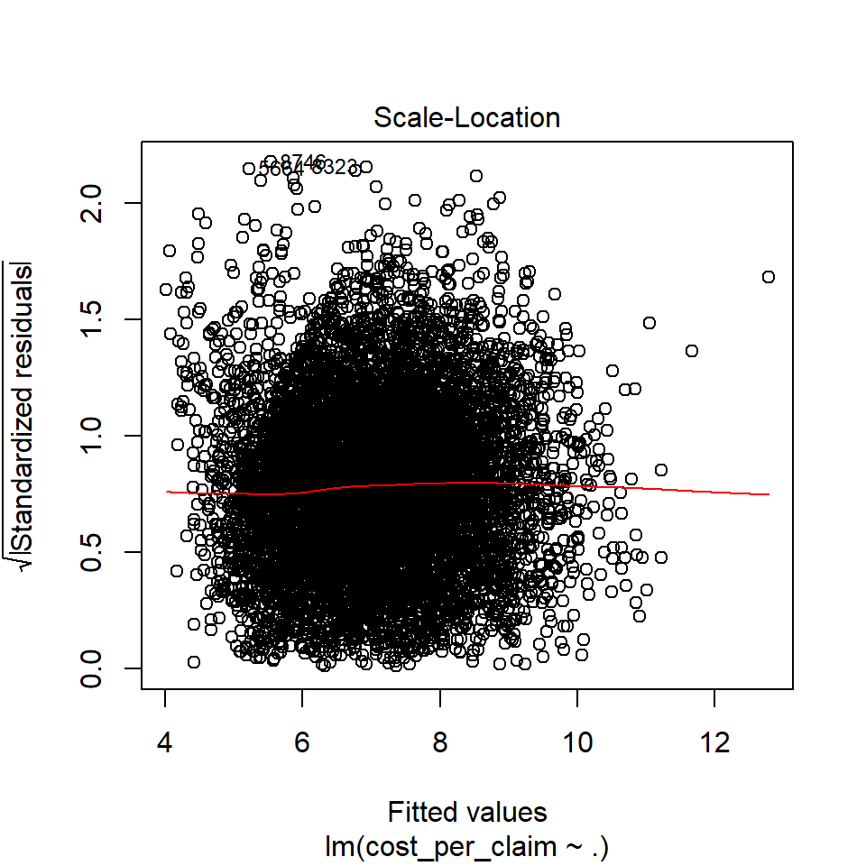

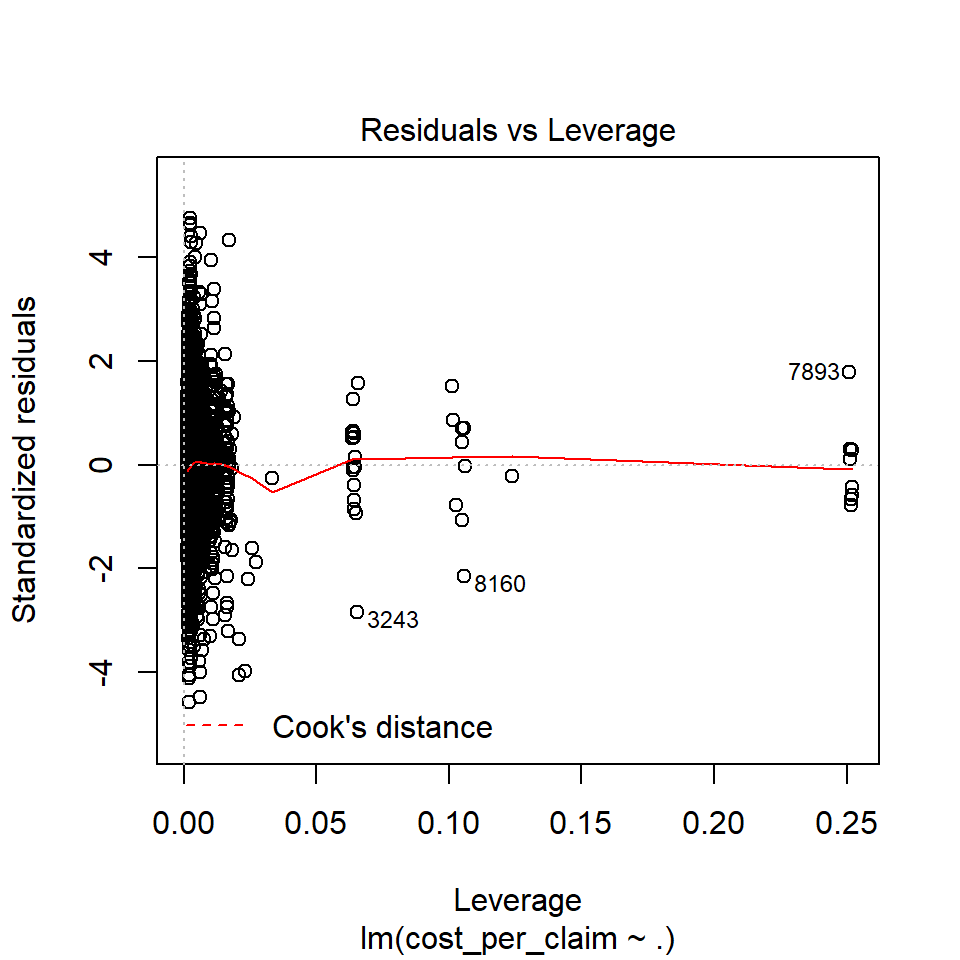

```r
plot(lm.cpc.fit1)
```

### **Random Forest**

Next a random forest model was fit with all variables. Again removing the variables actually increased the **MSE** on the validation set. Hence it was decided to keep a full model for random forest.

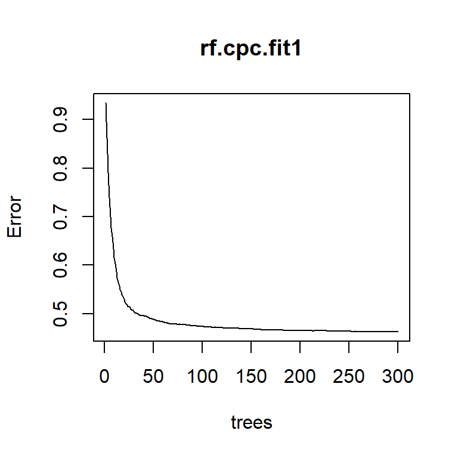

```r
set.seed(500)
rf.cpc.fit1<-randomForest(cost_per_claim ~ ., ntree = 300,data = training)
rf.mse1<-sum((predict(rf.cpc.fit1,testing)-testing$cost_per_claim)^2)/nrow(testing)
plot(rf.cpc.fit1)
```

Notable observations:

1. Unlike binary variable `claim_YN`, vehicle factors like `veh_value` and `veh_age` are coming out to be significant for `cost_per_claim`

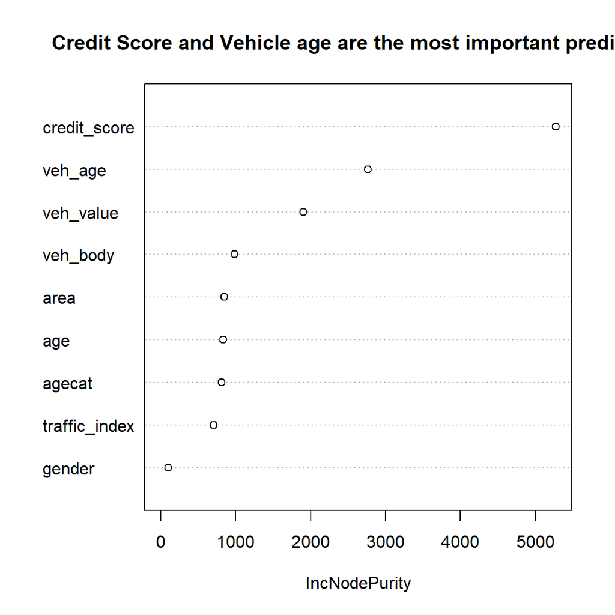

```r
varImpPlot(rf.cpc.fit1,type=2, main = "Credit Score and Vehicle age are the most important predictors")
```

### **Xtreme Boosting**

`Xgboost` was used to fit a thrid model. Here it was found that while full model was not best but removing `veh_age` was not appropriate unlike randomForest. So here we would be keeping `model 2`

**Model 1:** `cost_per_claim ~ .`

**Model 2:** `cost_per_claim ~ .- agecat`

**Model 3:** `cost_per_claim ~ .-veh_age -agecat`

```r
output_vector<-as.numeric(training[,"cost_per_claim"])
sparse_matrix_train <- sparse.model.matrix(cost_per_claim ~ ., data = training[,-3])[,-1]
sparse_matrix_test <- sparse.model.matrix(cost_per_claim ~ ., data = testing[,-3])[,-1]
set.seed(500)
xg.fit2 <- xgboost(data = sparse_matrix_train, label = output_vector, max_depth = 6,
                   eta = 0.3, nthread = 2, nrounds = 200,objective = "reg:linear")
importance <- xgb.importance(feature_names = colnames(sparse_matrix_train), model = xg.fit2)
xgb.mse2<-sum((predict(xg.fit2, sparse_matrix_test)-testing$cost_per_claim)^2)/nrow(testing)
```

Notable observation:

1. Same as random forest, vehicle factors and credit score are coming out to be important.

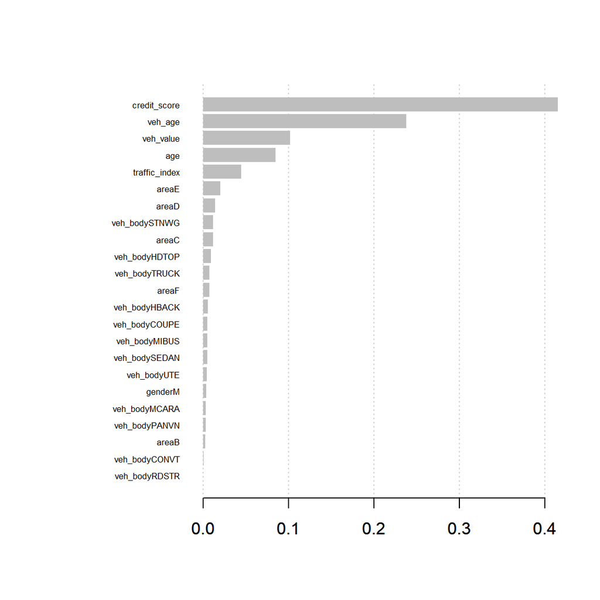

## **Final predictions**

Code below does anti-log of previously transformed `cost_per_claim` The file `potential_low_risky_customers.csv` which is getting extracted below would be having bottom 15% low risk customers.

```r
potential_risky<-data.frame(cbind(potential_risky,
                       "Cost_Per_Claim" = predict(lm.cpc.fit1,final_predictions[final_predictions$Quote.Numbers %in% potential_risky$Quote.Numbers,-c(1,11)])))
potential_risky$real_cost_per_claim<-exp(potential_risky$Cost_Per_Claim)
low_risky<-potential_risky %>%
  mutate(quantile = ntile(real_cost_per_claim, 100)) %>%
  filter(quantile<=15) %>% # Selecting las t15%iles to be low-risky customers (selection of cutoff depends on business)
  select(Quote.Numbers)
write.csv(low_risky,"potential_low_risky_customers.csv",row.names = FALSE)
```